# RTSS Project Report

October 04, 2017

## Experimental Design

Bulk RNASeq experiment assessing the effect of different stimulation on subjects treated with the RTSS malaria vaccine or comparator. There were a total of 1895 samples.

**Subjects**: 500 subjects.

**Vaccine**: rtss and comparator

**Location**: bagamoyo and manhica

**Age**: 6-12 weeks (young) and 5-17 months (old).

**Outcome**: control (no malaria) and case (malaria)

**Visit**: M0 and M3 (initial visit and 3 months later)

## Analysis

Reads were aligned using BWA Aln version 0.7.10. The transcriptome was downloaded from UCSC RefSeq (Human 19 or Mouse 10). Mitochondrial genes and ERCC reference sequences were added. Sequence alignment and quantification were run at Broad Technology Labs. The data was voom transformed and a linear model was applied for statistical testing.

There were 1764 samples and 11364 genes remaining after filtering.

## Sample Sizes: before sample filtering

There is a significant confound between age and location. Bagamoyo had samples only from the old age group and Manhica had mostly samples from the young age group.

Bagamoyo

|  | total | 5-17m | 6-12w | M0 | M3 | comparator | rtss | case | control |
| --- | --- | --- | --- | --- | --- | --- | --- | --- | --- |
| dmso | 319 | 319 | 0 | 116 | 203 | 112 | 207 | 49 | 124 |
| csp | 319 | 319 | 0 | 116 | 203 | 112 | 207 | 49 | 124 |
| hbs | 301 | 301 | 0 | 105 | 196 | 104 | 197 | 47 | 117 |
| ama1 | 278 | 278 | 0 | 97 | 181 | 93 | 185 | 45 | 98 |

Manhica

|  | total | 5-17m | 6-12w | M0 | M3 | comparator | rtss | case | control |
| --- | --- | --- | --- | --- | --- | --- | --- | --- | --- |
| dmso | 181 | 44 | 137 | 16 | 165 | 67 | 114 | 25 | 63 |
| csp | 181 | 44 | 137 | 16 | 165 | 67 | 114 | 25 | 63 |
| hbs | 172 | 40 | 132 | 16 | 156 | 60 | 112 | 24 | 60 |
| ama1 | 144 | 32 | 112 | 13 | 131 | 44 | 100 | 19 | 45 |

## Sample Sizes: after sample filtering

Bagamoyo

|  | total | 5-17m | 6-12w | M0 | M3 | comparator | rtss | case | control |
| --- | --- | --- | --- | --- | --- | --- | --- | --- | --- |
| dmso | 311 | 311 | 0 | 112 | 199 | 109 | 202 | 47 | 121 |
| csp | 311 | 311 | 0 | 112 | 199 | 108 | 203 | 49 | 121 |
| hbs | 294 | 294 | 0 | 101 | 193 | 101 | 193 | 46 | 114 |
| ama1 | 270 | 270 | 0 | 92 | 178 | 90 | 180 | 43 | 96 |

Manhica

|  | total | 5-17m | 6-12w | M0 | M3 | comparator | rtss | case | control |
| --- | --- | --- | --- | --- | --- | --- | --- | --- | --- |
| dmso | 161 | 32 | 129 | 11 | 150 | 61 | 100 | 19 | 61 |
| csp | 158 | 30 | 128 | 10 | 148 | 61 | 97 | 19 | 61 |
| hbs | 145 | 30 | 115 | 9 | 136 | 54 | 91 | 17 | 53 |
| ama1 | 114 | 23 | 91 | 9 | 105 | 34 | 80 | 13 | 35 |

## Samples lost due to filtering

There were a total of 131 samples removed due to low read counts.

The Manhica location had the majority of discarded samples, particularly for the 5-17m group, even though it had fewer samples than Bagamoyo and very few 5-17m samples.

Bagamoyo

|  | total | 5-17m | 6-12w | M0 | M3 | comparator | rtss | case | control |
| --- | --- | --- | --- | --- | --- | --- | --- | --- | --- |
| dmso | 8 | 8 | 0 | 4 | 4 | 3 | 5 | 2 | 3 |
| csp | 8 | 8 | 0 | 4 | 4 | 4 | 4 | 0 | 3 |
| hbs | 7 | 7 | 0 | 4 | 3 | 3 | 4 | 1 | 3 |
| ama1 | 8 | 8 | 0 | 5 | 3 | 3 | 5 | 2 | 2 |

Manhica

|  | total | 5-17m | 6-12w | M0 | M3 | comparator | rtss | case | control |
| --- | --- | --- | --- | --- | --- | --- | --- | --- | --- |
| dmso | 20 | 12 | 8 | 5 | 15 | 6 | 14 | 6 | 2 |
| csp | 23 | 14 | 9 | 6 | 17 | 6 | 17 | 6 | 2 |
| hbs | 27 | 10 | 17 | 7 | 20 | 6 | 21 | 7 | 7 |
| ama1 | 30 | 9 | 21 | 4 | 26 | 10 | 20 | 6 | 10 |

## Sample sizes by plate

There are no significant confounds by plate. Factors of biological interest are relatively balanced across plates.

Bagamoyo

|  | total | 5-17m | 6-12w | M0 | M3 | comparator | rtss | case | control |
| --- | --- | --- | --- | --- | --- | --- | --- | --- | --- |
| P1 | 264 | 264 | 0 | 81 | 183 | 122 | 142 | 43 | 113 |
| P2 | 232 | 232 | 0 | 79 | 153 | 74 | 158 | 54 | 78 |
| P3 | 234 | 234 | 0 | 75 | 159 | 66 | 168 | 36 | 78 |
| P4 | 230 | 230 | 0 | 100 | 130 | 82 | 148 | 36 | 82 |
| P5 | 257 | 257 | 0 | 99 | 158 | 77 | 180 | 21 | 112 |

Manhica

|  | total | 5-17m | 6-12w | M0 | M3 | comparator | rtss | case | control |
| --- | --- | --- | --- | --- | --- | --- | --- | --- | --- |
| P1 | 115 | 9 | 106 | 7 | 108 | 33 | 82 | 13 | 58 |
| P2 | 147 | 40 | 107 | 22 | 125 | 76 | 71 | 16 | 37 |
| P3 | 145 | 54 | 91 | 8 | 137 | 56 | 89 | 19 | 34 |
| P4 | 149 | 18 | 131 | 8 | 141 | 39 | 110 | 29 | 67 |
| P5 | 122 | 39 | 83 | 16 | 106 | 34 | 88 | 16 | 35 |

## Samples lost by filtering by plate

The samples lost were mostly from Manhica and plate 3 in particular.

Bagamoyo

|  | total | 5-17m | 6-12w | M0 | M3 | comparator | rtss | case | control |
| --- | --- | --- | --- | --- | --- | --- | --- | --- | --- |
| P1 | 0 | 0 | 0 | 0 | 0 | 0 | 0 | 0 | 0 |
| P2 | 11 | 11 | 0 | 5 | 6 | 8 | 3 | 3 | 5 |
| P3 | 16 | 16 | 0 | 11 | 5 | 3 | 13 | 1 | 5 |
| P4 | 3 | 3 | 0 | 0 | 3 | 2 | 1 | 1 | 0 |
| P5 | 1 | 1 | 0 | 1 | 0 | 0 | 1 | 0 | 1 |

Manhica

|  | total | 5-17m | 6-12w | M0 | M3 | comparator | rtss | case | control |
| --- | --- | --- | --- | --- | --- | --- | --- | --- | --- |
| P1 | 7 | 2 | 5 | 0 | 7 | 2 | 5 | 6 | 1 |
| P2 | 6 | 5 | 1 | 5 | 1 | 0 | 6 | 0 | 1 |
| P3 | 62 | 27 | 35 | 7 | 55 | 17 | 45 | 15 | 11 |
| P4 | 5 | 0 | 5 | 0 | 5 | 2 | 3 | 3 | 2 |
| P5 | 20 | 11 | 9 | 10 | 10 | 7 | 13 | 1 | 6 |

## Statistical Analysis

- Compare interaction effects between stimulants vs controls and vaccine (rtss vs comparator)
- Compare interaction effects between stimulants vs controls and disease (rtss vs comparator) separately for age groups (5-17m and 6-12w)
- Compare interaction effects of stimulants vs dmso and case vs control for subjects treated with rtss,s (comparator samples left out)
- Apply GSEA analysis (camera) to all comparisons using the Blood Transcriptional Modules (BTM)
- Apply individual gene testing (DEGs) to all comparisons
- A Bayesian variance shrinkage estimator and the Benjamini-Hochberg FDR were applied.
- An FDR cutoff of 0.2 was used for significance.
- Fold changes are calculated as stimulant - DMSO, rtss - comparator.

## DMSO vs csp:vaccine: both

No significant gene sets found

## DMSO vs csp:disease: both

### disease model for significant vaccine effects

No significant gene sets found

## DMSO vs csp:disease: both

No significant gene sets found

## DMSO vs csp:vaccine: young

|  | NGenes | Direction | PValue | FDR |
| --- | --- | --- | --- | --- |
| enriched in G-protein coupled receptors (M130) | 10 | Down | 0.000489 | 0.13 |

## DMSO vs csp:disease: young

### disease model for significant vaccine effects

|  | NGenes | Direction | PValue | FDR |
| --- | --- | --- | --- | --- |
| enriched in G-protein coupled receptors (M130) | 10 | Down | 0.293 | 0.293 |

## DMSO vs csp:disease: young

No significant gene sets found

## DMSO vs csp:vaccine: old

No significant gene sets found

## DMSO vs csp:disease: old

### disease model for significant vaccine effects

No significant gene sets found

## DMSO vs csp:disease: old

No significant gene sets found

## DMSO vs hbs:vaccine: both

|  | NGenes | Direction | PValue | FDR |
| --- | --- | --- | --- | --- |
| enriched in myeloid cells and monocytes (M81) | 23 | Up | 0.000483 | 0.0714 |
| CORO1A-DEF6 network (I) (M32.2) | 17 | Down | 0.000539 | 0.0714 |
| NK cell surface signature (S1) | 24 | Up | 0.00239 | 0.198 |
| respiratory electron transport chain (mitochondrion) (M231) | 11 | Down | 0.00327 | 0.198 |
| T cell activation and signaling (M5.1) | 22 | Down | 0.00425 | 0.198 |
| respiratory electron transport chain (mitochondrion) (M219) | 18 | Down | 0.00468 | 0.198 |
| signaling in T cells (II) (M35.1) | 10 | Up | 0.00524 | 0.198 |

## DMSO vs hbs:disease: both

### disease model for significant vaccine effects

|  | NGenes | Direction | PValue | FDR |
| --- | --- | --- | --- | --- |
| enriched in myeloid cells and monocytes (M81) | 23 | Down | 0.000712 | 0.00498 |
| respiratory electron transport chain (mitochondrion) (M231) | 11 | Down | 0.184 | 0.618 |
| NK cell surface signature (S1) | 24 | Up | 0.265 | 0.618 |
| T cell activation and signaling (M5.1) | 22 | Up | 0.406 | 0.65 |
| signaling in T cells (II) (M35.1) | 10 | Up | 0.464 | 0.65 |
| respiratory electron transport chain (mitochondrion) (M219) | 18 | Up | 0.622 | 0.726 |
| CORO1A-DEF6 network (I) (M32.2) | 17 | Up | 0.894 | 0.894 |

## DMSO vs hbs:disease: both

|  | NGenes | Direction | PValue | FDR |
| --- | --- | --- | --- | --- |
| enriched in myeloid cells and monocytes (M81) | 23 | Down | 0.000712 | 0.142 |
| enriched in monocytes (I) (M4.15) | 8 | Down | 0.00142 | 0.142 |
| TBA (M174) | 22 | Up | 0.00161 | 0.142 |

## DMSO vs hbs:vaccine: young

No significant gene sets found

## DMSO vs hbs:disease: young

### disease model for significant vaccine effects

No significant gene sets found

## DMSO vs hbs:disease: young

|  | NGenes | Direction | PValue | FDR |
| --- | --- | --- | --- | --- |
| respiratory electron transport chain (mitochondrion) (M231) | 11 | Down | 3.64e-06 | 0.000964 |
| transcription elongation, RNA polymerase II (M234) | 13 | Down | 0.00042 | 0.0557 |
| respiratory electron transport chain (mitochondrion) (M219) | 18 | Down | 0.000648 | 0.0573 |
| T cell differentiation (Th2) (M19) | 15 | Down | 0.00205 | 0.131 |
| respiratory electron transport chain (mitochondrion) (M216) | 12 | Down | 0.00261 | 0.131 |
| CORO1A-DEF6 network (II) (M32.4) | 13 | Down | 0.00405 | 0.131 |
| enriched in T cells (I) (M7.0) | 56 | Down | 0.00406 | 0.131 |
| translation initiation factor 3 complex (M245) | 11 | Down | 0.00427 | 0.131 |
| enriched in monocytes (I) (M4.15) | 8 | Down | 0.00446 | 0.131 |
| KLF12 targets network (M32.3) | 15 | Down | 0.00569 | 0.151 |

## DMSO vs hbs:vaccine: old

|  | NGenes | Direction | PValue | FDR |
| --- | --- | --- | --- | --- |
| NK cell surface signature (S1) | 24 | Up | 0.000636 | 0.117 |
| enriched in myeloid cells and monocytes (M81) | 23 | Up | 0.000886 | 0.117 |
| CORO1A-DEF6 network (I) (M32.2) | 17 | Down | 0.00139 | 0.123 |

## DMSO vs hbs:disease: old

### disease model for significant vaccine effects

|  | NGenes | Direction | PValue | FDR |
| --- | --- | --- | --- | --- |
| enriched in myeloid cells and monocytes (M81) | 23 | Down | 0.0141 | 0.0423 |
| CORO1A-DEF6 network (I) (M32.2) | 17 | Up | 0.0933 | 0.14 |
| NK cell surface signature (S1) | 24 | Up | 0.618 | 0.618 |

## DMSO vs hbs:disease: old

|  | NGenes | Direction | PValue | FDR |
| --- | --- | --- | --- | --- |
| TBA (M174) | 22 | Up | 0.000336 | 0.089 |
| chaperonin mediated protein folding (I) (M204.0) | 14 | Up | 0.000692 | 0.0916 |
| respiratory electron transport chain (mitochondrion) (M219) | 18 | Up | 0.00197 | 0.129 |
| respiratory electron transport chain (mitochondrion) (M238) | 17 | Up | 0.00199 | 0.129 |
| leukocyte differentiation (M160) | 14 | Up | 0.00244 | 0.129 |

## GSEA summary stimulation:vaccine interaction

### FDR cutoff: 0.2

Number of significant BTM gene sets for dmso versus stimulants and vaccine interaction.

|  | csp | hbs |
| --- | --- | --- |
| both | 0 | 7 |
| young | 1 | 0 |
| old | 0 | 3 |

## GSEA summary stimulation:disease interaction

### FDR cutoff: 0.2

Number of significant BTM gene sets for dmso versus stimulants and disease nteraction.

|  | csp | hbs |
| --- | --- | --- |
| both | 0 | 3 |
| young | 0 | 10 |
| old | 0 | 5 |

## DMSO vs csp:vaccine: both

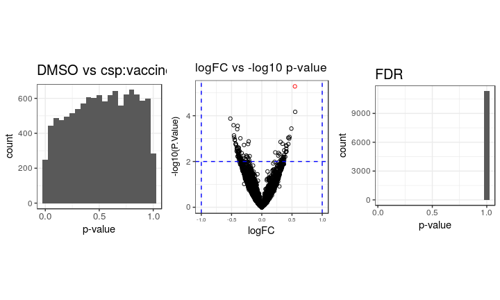

## DMSO vs csp:vaccine: both

|  | log FC | P.value | FDR |
| --- | --- | --- | --- |
| IL2 | 0.549 | 5.22e-06 | 0.0593 |
| FCGR2B | 0.553 | 6.78e-05 | 0.385 |
| VPS18 | -0.52 | 0.000133 | 0.505 |
| ARFGAP1 | -0.466 | 0.00026 | 0.628 |
| HBP1 | -0.398 | 0.000278 | 0.628 |
| STK40 | 0.49 | 0.000364 | 0.628 |
| RHOT2 | -0.406 | 0.000387 | 0.628 |
| DHX57 | -0.459 | 0.000727 | 0.871 |
| ZFYVE26 | 0.459 | 0.000846 | 0.871 |
| EGR2 | -0.455 | 0.000901 | 0.871 |

[output cut: 94 more lines]

## DMSO vs csp:disease: both

### disease model for significant vaccine effects

|  | logFC | P.Value | adj.P.Val |
| --- | --- | --- | --- |
| VPS18 | 0.775 | 0.00283 | 0.245 |
| SAV1 | 0.679 | 0.00648 | 0.245 |
| NBEAL2 | 0.694 | 0.00706 | 0.245 |
| TGDS | -0.512 | 0.0119 | 0.266 |
| NCOA2 | -0.602 | 0.0128 | 0.266 |
| ENDOD1 | -0.593 | 0.0236 | 0.409 |
| SYNJ2 | -0.579 | 0.0342 | 0.502 |
| MLLT4 | 0.526 | 0.0386 | 0.502 |
| FDX1 | -0.477 | 0.0497 | 0.535 |
| IL10RA | -0.419 | 0.0514 | 0.535 |

[output cut: 94 more lines]

## DMSO vs csp:disease: both

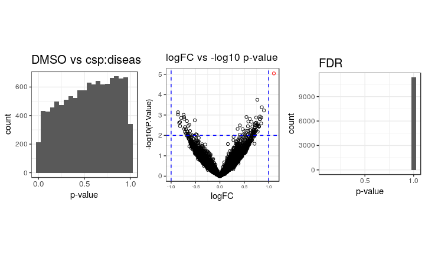

## DMSO vs csp:disease: both

|  | log FC | P.value | FDR |
| --- | --- | --- | --- |
| TMEM194A | 1.11 | 9.09e-06 | 0.103 |
| TRIM27 | 0.77 | 0.000177 | 1 |
| RNF135 | 0.861 | 0.000416 | 1 |
| MTUS1 | 0.904 | 0.000596 | 1 |
| TRAPPC5 | -0.858 | 0.000732 | 1 |
| TOP2A | -0.86 | 0.000929 | 1 |
| SND1 | -0.743 | 0.000982 | 1 |
| SIGLEC9 | 0.823 | 0.00119 | 1 |
| RAB1A | 0.545 | 0.00124 | 1 |
| TNRC6C | -0.733 | 0.00125 | 1 |

[output cut: 87 more lines]

## DMSO vs csp:vaccine: young

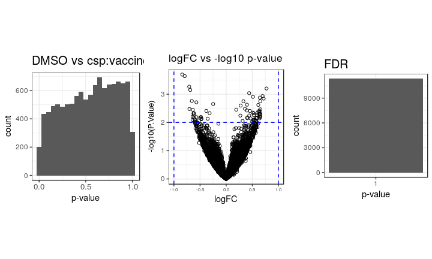

## DMSO vs csp:vaccine: young

|  | log FC | P.value | FDR |
| --- | --- | --- | --- |
| KLC1 | -0.841 | 0.000201 | 1 |
| NR2C2AP | -0.794 | 0.000228 | 1 |
| LDLRAD1 | -0.708 | 0.00054 | 1 |
| POLR2M | 0.773 | 0.000625 | 1 |
| TOLLIP | -0.687 | 0.000706 | 1 |
| METTL14 | 0.44 | 0.000915 | 1 |
| TM7SF2 | 0.698 | 0.00116 | 1 |
| SPTB | 0.513 | 0.00124 | 1 |
| C2orf88 | 0.645 | 0.00131 | 1 |
| SBDSP1 | 0.717 | 0.00143 | 1 |

[output cut: 66 more lines]

## DMSO vs csp:disease: young

### disease model for significant vaccine effects

|  | logFC | P.Value | adj.P.Val |
| --- | --- | --- | --- |
| RAB24 | -0.833 | 0.0171 | 0.481 |
| PHF15 | 0.878 | 0.0181 | 0.481 |
| COX14 | -0.413 | 0.019 | 0.481 |
| HERC2 | -0.695 | 0.0536 | 0.994 |
| PSME4 | -0.624 | 0.0756 | 0.994 |
| LRRC8C | -0.656 | 0.114 | 0.994 |
| C11orf74 | -0.716 | 0.118 | 0.994 |
| MGA | 0.432 | 0.122 | 0.994 |
| NCBP1 | -0.39 | 0.127 | 0.994 |
| UBA5 | -0.59 | 0.155 | 0.994 |

[output cut: 66 more lines]

## DMSO vs csp:disease: young

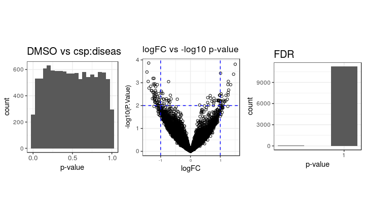

## DMSO vs csp:disease: young

|  | log FC | P.value | FDR |
| --- | --- | --- | --- |
| TNRC6C | -1.4 | 0.000137 | 0.876 |
| MDC1 | 1.5 | 0.000154 | 0.876 |
| ZNF471 | -1.46 | 0.000338 | 0.899 |
| HSPA4 | 1.01 | 0.000381 | 0.899 |
| KIAA1468 | 1.45 | 0.00042 | 0.899 |
| MGAT1 | -1.22 | 0.000641 | 0.899 |
| SLC35D1 | -1.26 | 0.000642 | 0.899 |
| EPG5 | 1.27 | 0.000868 | 0.899 |
| CCNG2 | -1.42 | 0.000871 | 0.899 |
| COX19 | -0.734 | 0.00089 | 0.899 |

[output cut: 99 more lines]

## DMSO vs csp:vaccine: old

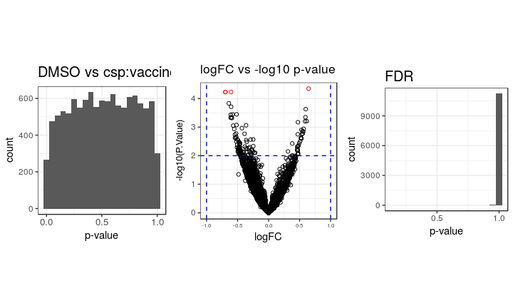

## DMSO vs csp:vaccine: old

|  | log FC | P.value | FDR |
| --- | --- | --- | --- |
| IL2 | 0.645 | 4.5e-05 | 0.168 |
| SAV1 | -0.604 | 5.85e-05 | 0.168 |
| VPS18 | -0.694 | 5.89e-05 | 0.168 |
| AAMDC | -0.697 | 5.93e-05 | 0.168 |
| E4F1 | -0.64 | 0.000147 | 0.333 |
| PNKP | -0.603 | 0.000193 | 0.366 |
| COPS7B | 0.599 | 0.000234 | 0.38 |
| HBP1 | -0.515 | 0.000355 | 0.389 |
| H2AFJ | -0.58 | 0.000357 | 0.389 |
| NDUFAF5 | -0.609 | 0.000366 | 0.389 |

[output cut: 101 more lines]

## DMSO vs csp:disease: old

### disease model for significant vaccine effects

|  | logFC | P.Value | adj.P.Val |
| --- | --- | --- | --- |
| SSBP2 | 0.786 | 0.00506 | 0.562 |
| ATP8B4 | 0.814 | 0.013 | 0.619 |
| MLLT4 | 0.8 | 0.0182 | 0.619 |
| IFRD2 | 0.75 | 0.0236 | 0.619 |
| SIGLEC16 | 0.802 | 0.0279 | 0.619 |
| USP22 | 0.307 | 0.038 | 0.636 |
| NDUFAF5 | 0.645 | 0.0406 | 0.636 |
| STK40 | -0.647 | 0.0554 | 0.636 |
| SAV1 | 0.539 | 0.0598 | 0.636 |
| CCDC50 | 0.33 | 0.0638 | 0.636 |

[output cut: 101 more lines]

## DMSO vs csp:disease: old

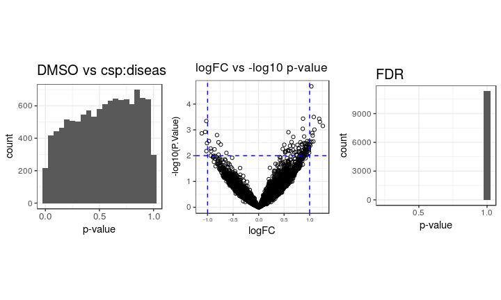

## DMSO vs csp:disease: old

|  | log FC | P.value | FDR |
| --- | --- | --- | --- |
| TPRG1L | 1.03 | 2.06e-05 | 0.234 |
| CRTC2 | 1.08 | 0.000315 | 0.924 |
| PSMD4 | 0.871 | 0.000367 | 0.924 |
| C9orf40 | 1.19 | 0.000374 | 0.924 |
| SND1 | -1.03 | 0.000454 | 0.924 |
| ASB1 | 1.2 | 0.000488 | 0.924 |
| RRS1 | 1.26 | 0.000703 | 0.999 |
| PTPMT1 | 0.866 | 0.000907 | 0.999 |
| STMN3 | 1.09 | 0.000976 | 0.999 |
| FBXL6 | -1.05 | 0.0012 | 0.999 |

[output cut: 88 more lines]

## DMSO vs hbs:vaccine: both

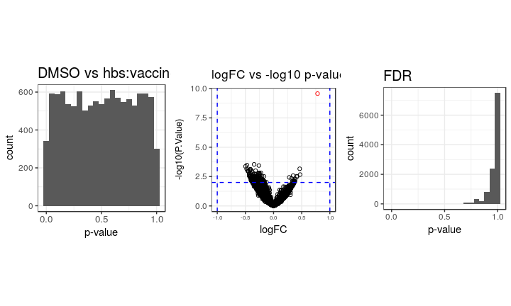

## DMSO vs hbs:vaccine: both

|  | log FC | P.value | FDR |
| --- | --- | --- | --- |
| IL2 | 0.781 | 2.69e-10 | 3.05e-06 |
| UBQLN1 | -0.345 | 0.000287 | 0.719 |
| CROT | -0.473 | 0.000332 | 0.719 |
| VDAC2 | -0.261 | 0.00036 | 0.719 |
| GATSL3 | -0.499 | 0.000426 | 0.719 |
| ZBTB49 | 0.464 | 0.00068 | 0.719 |
| WDR13 | -0.478 | 0.000715 | 0.719 |
| NEK7 | -0.414 | 0.000742 | 0.719 |
| MLKL | -0.408 | 0.000769 | 0.719 |
| DMAP1 | -0.418 | 0.0009 | 0.719 |

[output cut: 134 more lines]

## DMSO vs hbs:disease: both

### disease model for significant vaccine effects

|  | logFC | P.Value | adj.P.Val |
| --- | --- | --- | --- |
| KIAA1407 | 0.536 | 0.0109 | 0.834 |
| LY86-AS1 | -0.574 | 0.0317 | 0.834 |
| SNCB | 0.564 | 0.0364 | 0.834 |
| CDC37 | -0.376 | 0.0366 | 0.834 |
| NCOA2 | -0.511 | 0.0382 | 0.834 |
| SUPT4H1 | 0.341 | 0.0468 | 0.834 |
| ISCA2 | 0.492 | 0.0499 | 0.834 |
| ASAH1 | 0.362 | 0.0543 | 0.834 |
| ASCC3 | 0.323 | 0.0607 | 0.834 |
| GTF3A | -0.341 | 0.0643 | 0.834 |

[output cut: 134 more lines]

## DMSO vs hbs:disease: both

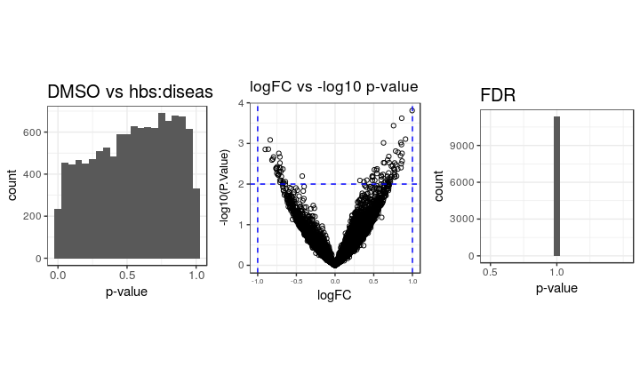

## DMSO vs hbs:disease: both

|  | log FC | P.value | FDR |
| --- | --- | --- | --- |
| EGR2 | 0.996 | 0.000155 | 1 |
| SLC39A3 | 0.862 | 0.000239 | 1 |
| GTPBP8 | 0.756 | 0.000364 | 1 |
| TMEM42 | 0.911 | 0.000781 | 1 |
| TNS3 | -0.838 | 0.000818 | 1 |
| C6orf70 | 0.849 | 0.000951 | 1 |
| UFD1L | 0.627 | 0.000967 | 1 |
| DAZAP1 | 0.859 | 0.00107 | 1 |
| PSMG4 | -0.862 | 0.00138 | 1 |
| SDHAF1 | -0.902 | 0.0014 | 1 |

[output cut: 84 more lines]

## DMSO vs hbs:vaccine: young

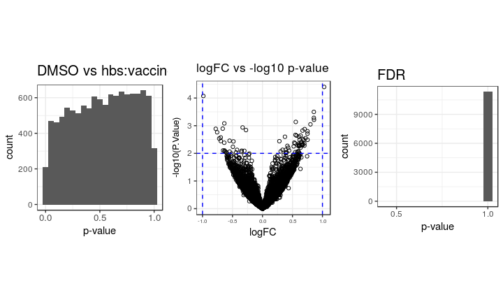

## DMSO vs hbs:vaccine: young

|  | log FC | P.value | FDR |
| --- | --- | --- | --- |
| ZNF767 | 1.03 | 3.97e-05 | 0.451 |
| ITPR3 | -0.986 | 8.4e-05 | 0.477 |
| VWA8 | 0.856 | 0.000317 | 1 |
| PKN1 | 0.857 | 0.00052 | 1 |
| ANKRD19P | 0.859 | 0.000612 | 1 |
| MRPS30 | 0.555 | 0.00073 | 1 |
| RHOT2 | -0.636 | 0.000824 | 1 |
| EXT2 | 0.8 | 0.000892 | 1 |
| VIMP | -0.332 | 0.00116 | 1 |
| DMAP1 | -0.663 | 0.00128 | 1 |

[output cut: 69 more lines]

## DMSO vs hbs:disease: young

### disease model for significant vaccine effects

|  | logFC | P.Value | adj.P.Val |
| --- | --- | --- | --- |
| EXT2 | -1.09 | 0.0135 | 0.409 |
| RBP1 | 0.913 | 0.0305 | 0.409 |
| CDC37 | -0.619 | 0.0317 | 0.409 |
| CDCP1 | 0.809 | 0.0394 | 0.409 |
| RP2 | 0.574 | 0.0407 | 0.409 |
| ATIC | -0.612 | 0.0451 | 0.409 |
| NLRP7 | 0.769 | 0.0459 | 0.409 |
| PLEKHF1 | -0.837 | 0.0485 | 0.409 |
| SPAG1 | -0.83 | 0.0491 | 0.409 |
| MARCH1 | -0.811 | 0.055 | 0.409 |

[output cut: 69 more lines]

## DMSO vs hbs:disease: young

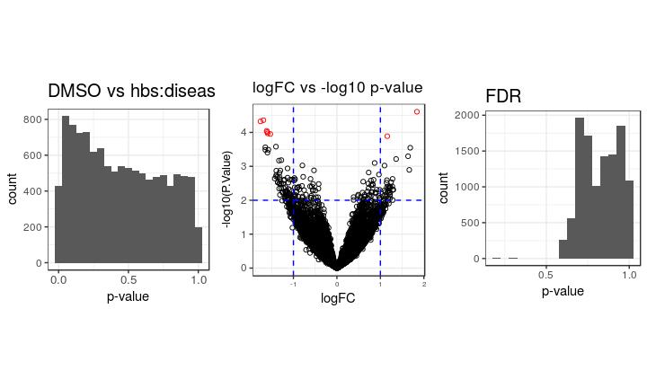

## DMSO vs hbs:disease: young

|  | log FC | P.value | FDR |
| --- | --- | --- | --- |
| SPAG6 | 1.84 | 2.45e-05 | 0.179 |
| ATP6V0D1 | -1.69 | 4.36e-05 | 0.179 |
| ZNF471 | -1.76 | 4.73e-05 | 0.179 |
| PTPRK | -1.62 | 9e-05 | 0.181 |
| SMG5 | -1.6 | 9.71e-05 | 0.181 |
| CEACAM1 | -1.59 | 0.000107 | 0.181 |
| TRAPPC9 | -1.53 | 0.000111 | 0.181 |
| SLC25A53 | 1.16 | 0.000129 | 0.183 |
| CETN2 | -1.4 | 0.000262 | 0.286 |
| TMED1 | -1.65 | 0.000274 | 0.286 |

[output cut: 172 more lines]

## DMSO vs hbs:vaccine: old

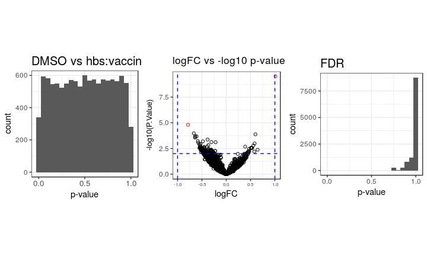

## DMSO vs hbs:vaccine: old

|  | log FC | P.value | FDR |
| --- | --- | --- | --- |
| IL2 | 1.01 | 3.02e-10 | 3.43e-06 |
| CDKL1 | -0.784 | 1.54e-05 | 0.0877 |
| SNCB | -0.667 | 0.000106 | 0.372 |
| POLDIP2 | 0.6 | 0.000131 | 0.372 |
| C16orf91 | -0.637 | 0.000194 | 0.379 |
| H2AFJ | -0.61 | 0.000208 | 0.379 |
| CHST2 | -0.638 | 0.000255 | 0.379 |
| RNF24 | -0.641 | 0.000267 | 0.379 |
| ASCC3 | -0.384 | 0.000424 | 0.535 |
| PRR3 | -0.583 | 0.000604 | 0.65 |

[output cut: 133 more lines]

## DMSO vs hbs:disease: old

### disease model for significant vaccine effects

|  | logFC | P.Value | adj.P.Val |
| --- | --- | --- | --- |
| DPH2 | 1.1 | 0.00101 | 0.144 |
| MGST2 | 0.906 | 0.00558 | 0.385 |
| HDAC9 | 0.896 | 0.00807 | 0.385 |
| DYNLT3 | 0.548 | 0.0151 | 0.453 |
| GIMAP2 | 0.504 | 0.0217 | 0.453 |
| FDX1L | 0.76 | 0.0249 | 0.453 |
| TGIF2 | 0.367 | 0.0252 | 0.453 |
| NCOA2 | -0.698 | 0.0269 | 0.453 |
| TBP | 0.64 | 0.0328 | 0.453 |
| H2AFJ | -0.693 | 0.0349 | 0.453 |

[output cut: 133 more lines]

## DMSO vs hbs:disease: old

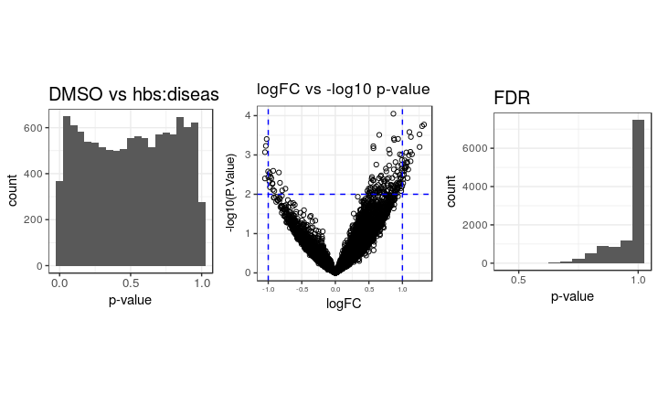

## DMSO vs hbs:disease: old

|  | log FC | P.value | FDR |
| --- | --- | --- | --- |
| LSM2 | 0.865 | 8.94e-05 | 0.429 |
| RGL2 | 1.32 | 0.000169 | 0.429 |
| CIDECP | 1.29 | 0.000185 | 0.429 |
| PMFBP1 | 1.1 | 0.000261 | 0.429 |
| DTHD1 | 1.26 | 0.000299 | 0.429 |
| LSM14A | 0.655 | 0.000309 | 0.429 |
| PGRMC1 | 1.13 | 0.000347 | 0.429 |
| GPN1 | 0.872 | 0.000381 | 0.429 |
| C5orf22 | 0.935 | 0.00039 | 0.429 |
| PHLPP2 | -1.02 | 0.000394 | 0.429 |

[output cut: 144 more lines]

## DEG summary stimulation vaccine interaction

### FDR cutoff: 0.2

Number of significant genes for dmso versus stimulants and vaccine interaction.

|  | csp | hbs |
| --- | --- | --- |
| both | 1 | 1 |
| young | 0 | 0 |
| old | 4 | 2 |

## DEG summary stimulation disease interaction

### FDR cutoff: 0.2

|  | csp | hbs |
| --- | --- | --- |
| both | 1 | 0 |
| young | 0 | 8 |
| old | 0 | 0 |

## SessionInfo

R Under development (unstable) (2017-01-15 r71979) Platform: x86_64-pc-linux-gnu (64-bit) Running under: Ubuntu 14.04.2 LTS

locale: [1] LC_CTYPE=en_US.UTF-8 LC_NUMERIC=C  
[3] LC_TIME=en_US.UTF-8 LC_COLLATE=en_US.UTF-8  
[5] LC_MONETARY=en_US.UTF-8 LC_MESSAGES=en_US.UTF-8  
[7] LC_PAPER=en_US.UTF-8 LC_NAME=C  
[9] LC_ADDRESS=C LC_TELEPHONE=C  
[11] LC_MEASUREMENT=en_US.UTF-8 LC_IDENTIFICATION=C

attached base packages: [1] stats4 parallel stats graphics grDevices utils datasets [8] methods base

other attached packages: [1] heatmap3_1.1.1 cowplot_0.8.0  
[3] plotly_4.7.1 stringr_1.2.0  
[5] plyr_1.8.4 DT_0.2  
[7] GSEABase_1.38.2 graph_1.54.0  
[9] annotate_1.54.0 XML_3.98-1.9  
[11] AnnotationDbi_1.38.2 xtable_1.8-2  
[13] DESeq2_1.16.1 SummarizedExperiment_1.6.5 [15] DelayedArray_0.2.7 matrixStats_0.52.2  
[17] GenomicRanges_1.28.5 GenomeInfoDb_1.12.2  
[19] IRanges_2.10.3 S4Vectors_0.14.5  
[21] edgeR_3.18.1 limma_3.32.7  
[23] gridExtra_2.3 ggplot2_2.2.1  
[25] data.table_1.10.4 Biobase_2.36.2  
[27] BiocGenerics_0.22.0 knitr_1.17  
[29] BiocInstaller_1.26.1

loaded via a namespace (and not attached): [1] httr_1.3.1 tidyr_0.7.1  
[3] viridisLite_0.2.0 jsonlite_1.5  
[5] bit64_0.9-7 splines_3.4.0  
[7] assertthat_0.2.0 Formula_1.2-2  
[9] latticeExtra_0.6-28 blob_1.1.0  
[11] GenomeInfoDbData_0.99.0 yaml_2.1.14  
[13] RSQLite_2.0 backports_1.1.1  
[15] lattice_0.20-34 glue_1.1.1  
[17] digest_0.6.12 RColorBrewer_1.1-2  
[19] XVector_0.16.0 checkmate_1.8.4  
[21] colorspace_1.3-2 htmltools_0.3.6  
[23] Matrix_1.2-7.1 pkgconfig_2.0.1  
[25] genefilter_1.58.1 zlibbioc_1.22.0  
[27] purrr_0.2.3 scales_0.5.0  
[29] BiocParallel_1.10.1 htmlTable_1.9  
[31] tibble_1.3.4 fastcluster_1.1.24  
[33] nnet_7.3-12 lazyeval_0.2.0  
[35] survival_2.41-3 magrittr_1.5  
[37] memoise_1.1.0 evaluate_0.10.1  
[39] foreign_0.8-67 tools_3.4.0  
[41] munsell_0.4.3 locfit_1.5-9.1  
[43] cluster_2.0.5 bindrcpp_0.2  
[45] compiler_3.4.0 rlang_0.1.2  
[47] grid_3.4.0 RCurl_1.95-4.8  
[49] htmlwidgets_0.9 labeling_0.3  
[51] bitops_1.0-6 base64enc_0.1-3  
[53] rmarkdown_1.6 gtable_0.2.0  
[55] DBI_0.7 R6_2.2.2  
[57] dplyr_0.7.4 bit_1.1-12  
[59] bindr_0.1 Hmisc_4.0-3  
[61] rprojroot_1.2 stringi_1.1.5  
[63] Rcpp_0.12.13 geneplotter_1.54.0  
[65] rpart_4.1-10 acepack_1.4.1